# Dynamic Reporting with RMarkdown

Universal Template (PDF, HTML, Word)

2025-12-30

Abstract

This document serves as a universal template. It is designed to be rendered into HTML, PDF, or MS Word without requiring changes to the code. It demonstrates automatic table formatting and bibliography handling.

# 1 Introduction

This report demonstrates how to write **one** RMarkdown file that compiles cleanly to PDF, HTML, and Word. We avoid using `kableExtra` or raw `<div>` tags, relying instead on pure Pandoc Markdown.

# 2 Tables

To ensure tables look good in Word, PDF, and HTML simultaneously, we use `knitr::kable` with the markdown format.

```r
head(mtcars[, 1:4]) |>
  kable(caption = "A Universal Table Example",
        format = "markdown")  # "markdown" format is safest for cross-compatibility
```

A Universal Table Example

|  | mpg | cyl | disp | hp |
| --- | --- | --- | --- | --- |
| Mazda RX4 | 21.0 | 6 | 160 | 110 |
| Mazda RX4 Wag | 21.0 | 6 | 160 | 110 |
| Datsun 710 | 22.8 | 4 | 108 | 93 |
| Hornet 4 Drive | 21.4 | 6 | 258 | 110 |
| Hornet Sportabout | 18.7 | 8 | 360 | 175 |
| Valiant | 18.1 | 6 | 225 | 105 |

# 3 Graphics

## 3.1 Standard Vector Graphics

Standard graphics are rendered as vectors (in PDF) or high-quality images (HTML/Word) by default.

Graphics can be embedded into the documents as shown below.

### 3.1.1 Package: base

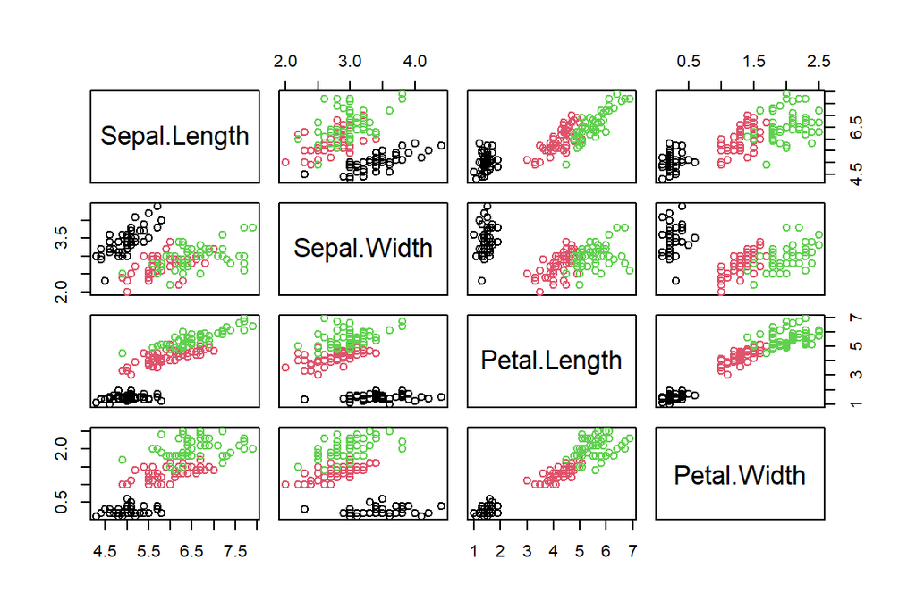

This is a **base** graphic

### 3.1.2 Package: ggplot2

See the cheat sheet for ggplot2 graphics for details: https://posit.co/wp-content/uploads/2022/10/data-visualization-1.pdf

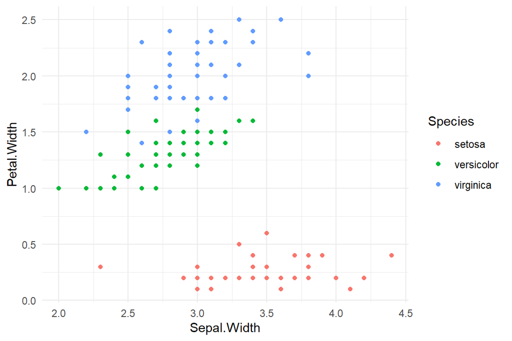

**ggplot** graphic. Captions with dynamic content are also possible, e.g., Date and Time: 2025-12-30 01:00:01.726949

The use of chunk options to set captions allows for dynamic numbering and list of figures generation. This works also for `base` graphics (see above). Check the chunk option `fig.asp=0.5` that is responsible for the altered aspect ratio.

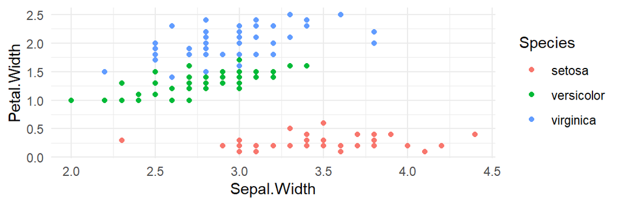

**ggplot** graphic with different aspect ratio.

```r
ggplot(iris, aes(x = Sepal.Width, y = Petal.Width)) +
  geom_point(aes(color = Species))
```

## 3.2 Large Datasets & Rasterization

When plotting datasets with thousands of points (like the `diamonds` dataset), vector graphics can make the final file huge and slow to load.

To solve this, we use the chunk option `dev='png'` and `dpi=300`. This forces this specific plot to render as a flat image (raster), keeping the document size small while maintaining transparency.

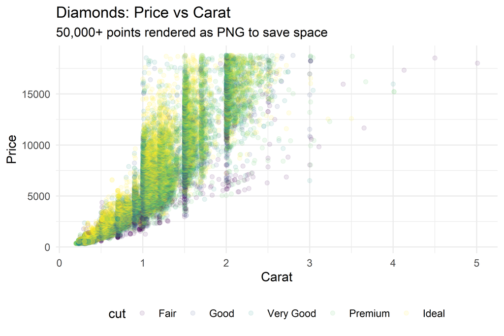

```r
# The 'alpha' parameter adds transparency to reveal density
diamonds %>%
ggplot(aes(x = carat, y = price, color = cut)) +
  geom_point(alpha = 0.1) +
  labs(title = "Diamonds: Price vs Carat",
       subtitle = "50,000+ points rendered as PNG to save space",
       x = "Carat",
       y = "Price") +
  theme(legend.position = "bottom")
```

# 4 Summary Statistics

We can also include raw text outputs, which are rendered as code blocks in all formats.

```r
summary(mtcars$mpg)
```

```
##    Min. 1st Qu.  Median    Mean 3rd Qu.    Max.
##   10.40   15.43   19.20   20.09   22.80   33.90
```

# 5 Citations

The information about the citations used are stored in `bibtex` style in the additional file `references.bib` which the last line of the YAML header is referencing to.

You can cite entries using the syntax `[@key]`.

We are using the **knitr** package (Xie 2025) for processing and **ggplot2** (Wickham et al. 2025) for visualization. References will be placed automatically at the end of the document or where we specify the placement div.

There are alternative ways to cite:

- Indirect citation: This report was built using the knitr package (Xie 2025).
- Direct citation: Wickham et al. (2025) describes the grammar of graphics.
- Multiple citations: RMarkdown is powerful (Allaire et al. 2025; Xie 2025).

# 6 Literature

Allaire, JJ, Yihui Xie, Christophe Dervieux, Jonathan McPherson, Javier Luraschi, Kevin Ushey, Aron Atkins, et al. 2025. *Rmarkdown: Dynamic Documents for r*. https://github.com/rstudio/rmarkdown.

Wickham, Hadley, Winston Chang, Lionel Henry, Thomas Lin Pedersen, Kohske Takahashi, Claus Wilke, Kara Woo, Hiroaki Yutani, Dewey Dunnington, and Teun van den Brand. 2025. *Ggplot2: Create Elegant Data Visualisations Using the Grammar of Graphics*. https://ggplot2.tidyverse.org.

Xie, Yihui. 2025. *Knitr: A General-Purpose Package for Dynamic Report Generation in r*. https://yihui.org/knitr/.

# 7 Appendix